# Spatial-Temporal Distribution of Kinkajous in a Balsa Tree

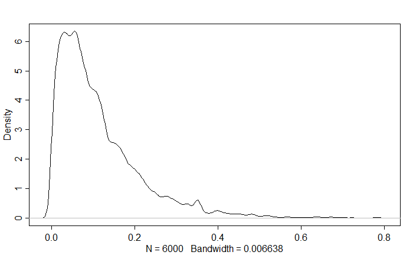

```r
samples <- extract.samples(residence_by_region_relative_density_stan_fit)



dens(samples$p[,1]) #check if this is probability of 0 or 1
```

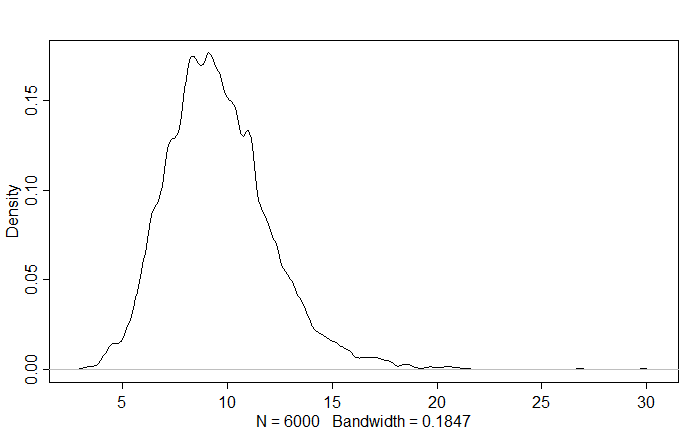

```r
dens(samples$mu[,1])
```

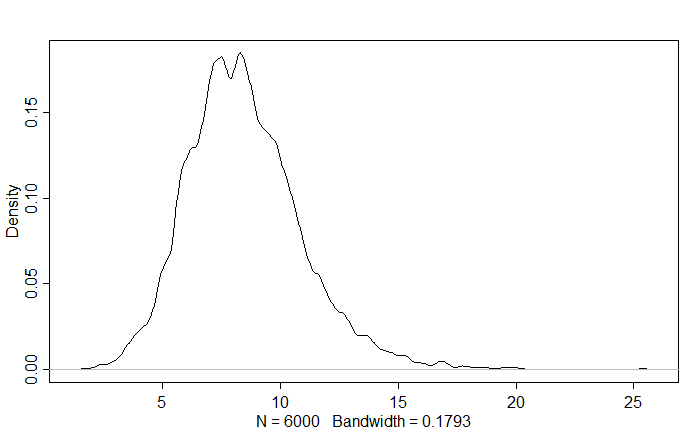

```r
prediction1 <- (1-samples$p[,1]) * samples$mu[,1]

dens(prediction1)
```

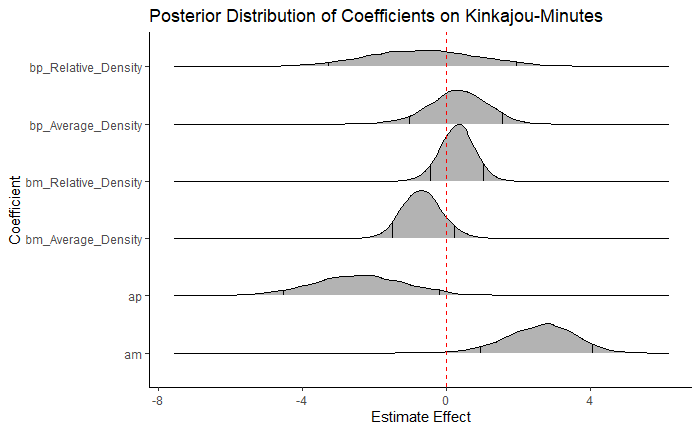

There a a few takeaways this plot of the posterior distributions of main coefficients. First, there is no discernible effect of either the total number of flowers in the tree or the relative density of foweris in a region on the probability of observing a 0 (no kinkajous showed up). There also does not appear to be much effect of relative density on the average time kinkajous spend in a region when they do show up. There is mild support for a negative effect of the average flower density on kinkajous residence times, with nearly 89% of estimates for this coefficient falling below zero. As noted previously in this documents, that appears related to a mild decline in kinkajou residence times toward the end of the study, when flower counts are greatest. THis may be caused by increasing availability of other resources during this time.

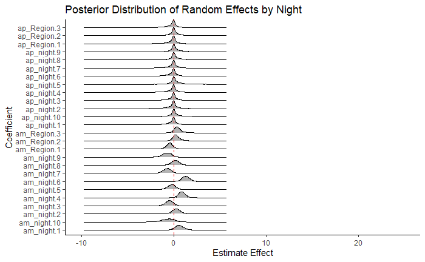

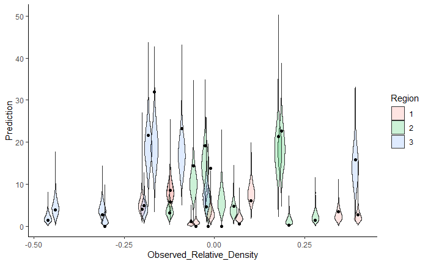

```r
relative_density_data <- residence_by_region_relative_density_stan_fit@data

#vioplot((1-samples$p) * samples$mu)
#plot(x = relative_density_data$Relative_Density, y = relative_density_data$Minutes_Per_Hour)

predictions <- ((1 - samples$p) * samples$mu) %>% data.frame %>%
  mutate(Draw = 1:n()) %>%
  pivot_longer(cols = -Draw, names_to = "Observation_Number", values_to = "Prediction") %>%
  mutate(Observation_Number = Observation_Number %>% strsplit(split = "") %>% sapply(function(X) paste(X[-1], collapse = "")) %>% as.numeric) %>%
  mutate(Observed_Relative_Density = relative_density_data$Relative_Density[Observation_Number],
         Region = factor(relative_density_data$Region[Observation_Number]))

ggplot(predictions) + geom_violin(aes(y = Prediction, x = Observed_Relative_Density, group = cut_width(Observation_Number, 1), fill = Region), scale = "width", width = 0.02, alpha = 0.2) +
  geom_point(data = data.frame(relative_density_data[1:5]), aes(x = Relative_Density, y = Minutes_Per_Hour)) + theme_classic()
```

#### Kinkajou Decisions

```r
decision_model <- ulam(
  alist(
    Success ~ binomial(1, p),
    save> logit(p) <-  ap + ap_From_To[From_To] + bp_flowers * relative_density_diff,
    #priors below
    ap ~ dnorm(0,2), #prior centers initial probability distribution of successful transition at 50%
    ap_From_To[From_To] ~ dnorm(0, ap_sigma_choice), #prior distribution on random effects of region (probability of 0)
    bp_flowers ~ dnorm(0, 2), #prior distribution on effect of flower density differential on success rate
    ap_sigma_choice ~ dexp(1)), #prior distributions for variance parameters,
  data = decisions %>%
    mutate(decisions, relative_density_diff = abs(relative_density_diff)) %>%
    select(relative_density_diff, From_To, Success) %>%
    na.omit(),
  cores=4 ,
  chains=4 ,
  warmup=1500,
  iter=3000,
  constraints=list(ap_sigma_choice="lower=0")
)

save(decision_model, file = "../Results/decision_model.Rdata")
stancode(decision_model)
```

```r
load("../Results/decision_model.Rdata")
#Get predictions from each sample of the posterior for each night in the study
precis(decision_model)
```

```
76 vector or matrix parameters hidden. Use depth=2 to show them.
```

|  | mean | sd | 5.5% | 94.5% | n_eff | Rhat4 |
| --- | --- | --- | --- | --- | --- | --- |
| ap | 0.38 | 0.68 | -0.70 | 1.43 | 1793 | 1 |
| bp_flowers | 0.34 | 1.24 | -1.67 | 2.32 | 4521 | 1 |
| ap_sigma_choice | 1.27 | 0.57 | 0.56 | 2.28 | 2298 | 1 |

```
76 vector or matrix parameters hidden. Use depth=2 to show them.
```

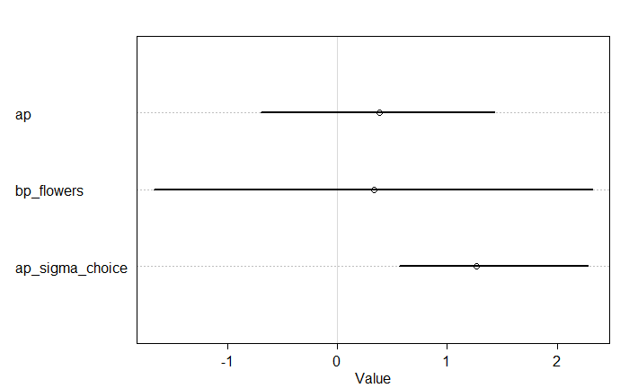

```r
plot(decision_model)
```

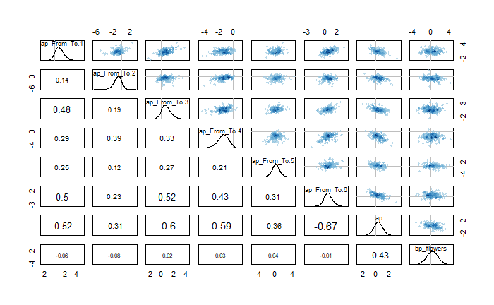

```r
pairs(decision_model, pars = c("ap_From_To", "ap", "bp_flowers"))
```

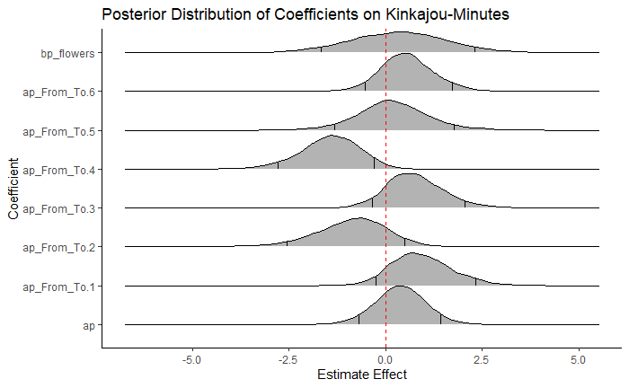

```r
decision_samples_long <- decision_model %>%
  gather_draws(ap, bp_flowers,
               #can't get regular expressions to work in this, so have to write everything manually /:
               ap_From_To.1,ap_From_To.2,ap_From_To.3,ap_From_To.4,ap_From_To.5,ap_From_To.6,
               )


#determine and plot average predictions with 89% CIs
decision_samples_long %>%
  ggplot() +
  stat_density_ridges(aes(x = .value, y = .variable), scale = 1, quantile_lines = TRUE, quantiles = c(0.055, 0.945)) + #the quantile lines on total flowers look wrong . . .
  geom_vline(xintercept = 0, color = "red", linetype = "dashed") +
  theme_classic() +
  labs(title = "Posterior Distribution of Coefficients on Kinkajou-Minutes",
       x = "Estimate Effect",
       y = "Coefficient")
```

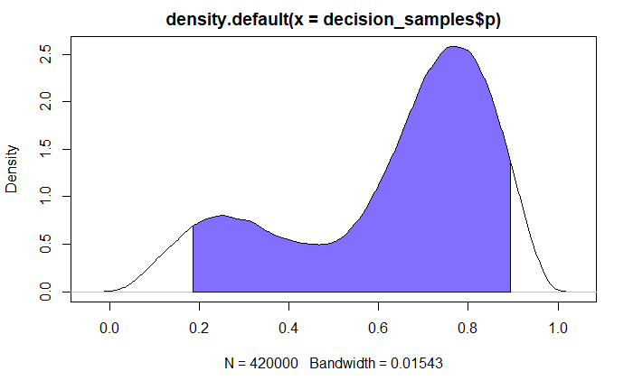

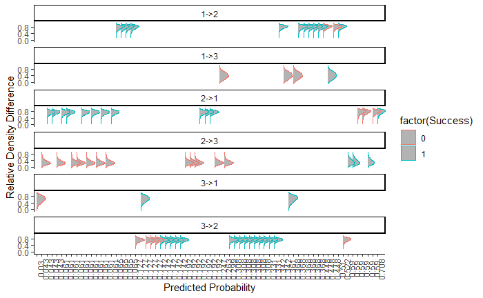

#### Social Displacement

```r
social_model <- ulam(
  alist(
    Departures ~ binomial(n, p),
    save> logit(p) <-  ap + ap_Region[Region] + ap_Night[Study_Night] + bp_n * n + bp_Neighbors * Neighbors,
    #priors below
    ap ~ dnorm(0,2), #prior centers initial probability distribution of departure at 50%
    ap_Region[Region] ~ dnorm(0, ap_sigma_Region), #prior distribution on random effects of region
    ap_Night[Study_Night] ~ dnorm(0, ap_sigma_Night), #prior distribution on random effects of Study Night
    c(bp_n, bp_Neighbors) ~ dnorm(0, 2), #prior distributions on effect of number of kinkajous in the region of interest and number of kinkajous in other regions on departure rates
    c(ap_sigma_Region, ap_sigma_Night) ~ dexp(1)), #prior distributions for variance parameters,
  data = departures_long %>%
    mutate(Study_Night = factor(Study_Night)) %>%
    select(!Minute) %>%
    na.omit(),
  cores=4 ,
  chains=4 ,
  warmup=1500,
  iter=3000,
  constraints=list(ap_sigma_Region="lower=0", ap_sigma_Night="lower=0")
)

save(social_model, file = "../Results/social_model.Rdata")
stancode(social_model)
```

```r
load("../Results/social_model.Rdata")
#Get predictions from each sample of the posterior for each night in the study
precis(social_model)
```

```
1592 vector or matrix parameters hidden. Use depth=2 to show them.
```

|  | mean | sd | 5.5% | 94.5% | n_eff | Rhat4 |
| --- | --- | --- | --- | --- | --- | --- |
| ap | -1.95 | 0.32 | -2.41 | -1.47 | 1680 | 1 |
| bp_Neighbors | 0.14 | 0.12 | -0.04 | 0.34 | 3614 | 1 |
| bp_n | 0.30 | 0.14 | 0.07 | 0.52 | 5159 | 1 |
| ap_sigma_Night | 0.45 | 0.14 | 0.25 | 0.70 | 1183 | 1 |
| ap_sigma_Region | 0.31 | 0.32 | 0.04 | 0.87 | 1438 | 1 |

```
1592 vector or matrix parameters hidden. Use depth=2 to show them.
```

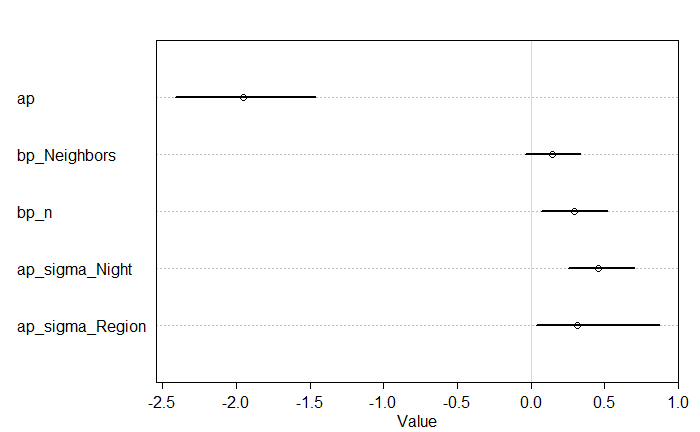

```r
plot(social_model)
```

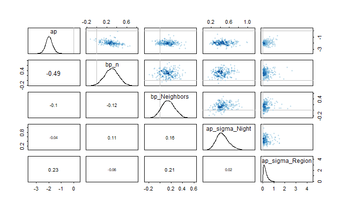

```r
pairs(social_model, pars = c("ap", "bp_n", "bp_Neighbors", "ap_sigma_Night", "ap_sigma_Region"))
```

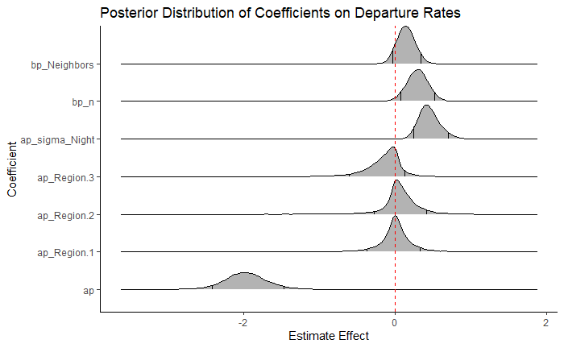

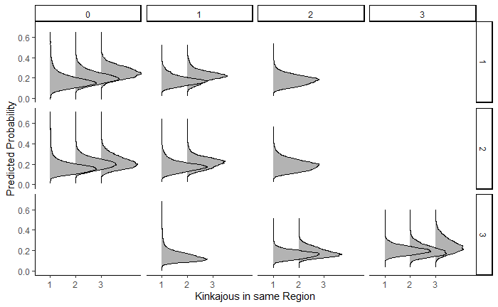